# RFmstate Demo: Custom Clinical Data with Date Variables

All sections use one configuration: seed 42, 300 subjects, 200 trees per edge, and the predictor set declared during data preparation. These values keep the source render practical and are not event-count or tuning recommendations.

## 1. Simulate Raw Clinical Data

We simulate a dataset with date-based event times, as one might receive from a clinical database. Patients start treatment and may experience heart failure, be cured, or die. **Cured** and **Death** are absorbing states; **Heart Failure** is a transient intermediate state.

```r
set.seed(canonical_seed)
n <- canonical_n

record_id <- seq_len(n)
gender <- sample(c("Male", "Female"), n, replace = TRUE)
trt <- sample(c("Drug A", "Drug B"), n, replace = TRUE)
weight <- round(rnorm(n, mean = 75, sd = 15), 1)

# Treatment start dates spread over 2 years
trt_date <- as.Date("2020-01-01") + sample(0:730, n, replace = TRUE)

# Simulate trajectories manually
heart_failure_date <- rep(as.Date(NA), n)
cured_date <- rep(as.Date(NA), n)
death_date <- rep(as.Date(NA), n)
last_followup_date <- rep(as.Date(NA), n)

for (i in seq_len(n)) {
  # From Treatment state, competing events:
  #   -> Heart Failure (rate depends on weight, treatment)
  #   -> Cured (rate depends on treatment)
  #   -> Death (rate depends on weight)
  trt_effect <- ifelse(trt[i] == "Drug A", 0.7, 1.0)
  wt_effect <- exp((weight[i] - 75) / 50)

  t_hf <- rweibull(1, shape = 1.3, scale = 300 * trt_effect * wt_effect)
  t_cured <- rweibull(1, shape = 1.5, scale = 250 / trt_effect)
  t_death <- rweibull(1, shape = 1.0, scale = 800 * (1 / wt_effect))

  first_wait_days <- pmax(1L, ceiling(c(t_hf, t_cured, t_death)))
  first_event <- which.min(first_wait_days)
  first_day <- first_wait_days[first_event]

  # Censoring at 3 years. Integer-day waits are rounded upward and constrained
  # to at least one day so the date representation cannot create zero-duration
  # sojourns.
  cens_day <- max(1L, ceiling(runif(1, 400, 1095)))

  if (first_day >= cens_day) {
    # Censored from Treatment state
    last_followup_date[i] <- trt_date[i] + cens_day
    next
  }

  if (first_event == 1) {
    # Heart Failure reached
    heart_failure_date[i] <- trt_date[i] + first_day

    # From Heart Failure: -> Cured or -> Death
    t_cured2 <- rweibull(1, shape = 1.4, scale = 200 / trt_effect)
    t_death2 <- rweibull(1, shape = 1.2, scale = 400 * (1 / wt_effect))

    second_wait_days <- pmax(1L, ceiling(c(t_cured2, t_death2)))
    second_event <- which.min(second_wait_days)
    second_day <- first_day + second_wait_days[second_event]

    if (second_day >= cens_day) {
      last_followup_date[i] <- trt_date[i] + cens_day
    } else if (second_event == 1) {
      cured_date[i] <- trt_date[i] + second_day
    } else {
      death_date[i] <- trt_date[i] + second_day
    }
  } else if (first_event == 2) {
    cured_date[i] <- trt_date[i] + first_day
  } else {
    death_date[i] <- trt_date[i] + first_day
  }
}

raw_data <- data.frame(
  record_id = record_id,
  gender = gender,
  trt = trt,
  weight = weight,
  trt_date = trt_date,
  cured_date = cured_date,
  heart_failure_date = heart_failure_date,
  death_date = death_date,
  last_followup_date = last_followup_date,
  stringsAsFactors = FALSE
)

head(raw_data, 10)
```

```
#>    record_id gender    trt weight   trt_date cured_date heart_failure_date
#> 1          1   Male Drug A   74.9 2021-11-08       <NA>         2022-04-17
#> 2          2   Male Drug B   86.4 2021-04-26 2021-10-23               <NA>
#> 3          3   Male Drug B   75.6 2021-11-18 2022-03-06               <NA>
#> 4          4   Male Drug B   86.0 2021-10-31 2022-04-14               <NA>
#> 5          5 Female Drug A   72.8 2021-12-29 2022-10-06         2022-01-04
#> 6          6 Female Drug A   74.1 2020-04-03 2020-09-03         2020-04-06
#> 7          7 Female Drug B   82.2 2020-07-19       <NA>               <NA>
#> 8          8 Female Drug A   89.9 2020-10-19 2021-02-06               <NA>
#> 9          9   Male Drug A   56.3 2021-12-21       <NA>         2022-06-04
#> 10        10 Female Drug B   74.5 2020-08-23 2020-12-01               <NA>
#>    death_date last_followup_date
#> 1        <NA>         2022-12-21
#> 2        <NA>               <NA>
#> 3        <NA>               <NA>
#> 4        <NA>               <NA>
#> 5        <NA>               <NA>
#> 6        <NA>               <NA>
#> 7  2020-08-24               <NA>
#> 8        <NA>               <NA>
#> 9        <NA>         2023-05-24
#> 10       <NA>               <NA>
```

## 2. Compute Time-to-Event from Treatment Date

Convert date columns to days since treatment start.

```r
dat <- data.frame(
  record_id = raw_data$record_id,
  gender = as.integer(raw_data$gender == "Male"),
  trt = as.integer(raw_data$trt == "Drug A"),
  weight = raw_data$weight,
  time_HeartFailure = as.numeric(
    difftime(raw_data$heart_failure_date, raw_data$trt_date, units = "days")
  ),
  time_Cured = as.numeric(
    difftime(raw_data$cured_date, raw_data$trt_date, units = "days")
  ),
  time_Death = as.numeric(
    difftime(raw_data$death_date, raw_data$trt_date, units = "days")
  ),
  time_censored = as.numeric(
    difftime(raw_data$last_followup_date, raw_data$trt_date, units = "days")
  ),
  stringsAsFactors = FALSE
)

head(dat, 10)
```

```
#>    record_id gender trt weight time_HeartFailure time_Cured time_Death
#> 1          1      1   1   74.9               160         NA         NA
#> 2          2      1   0   86.4                NA        180         NA
#> 3          3      1   0   75.6                NA        108         NA
#> 4          4      1   0   86.0                NA        165         NA
#> 5          5      0   1   72.8                 6        281         NA
#> 6          6      0   1   74.1                 3        153         NA
#> 7          7      0   0   82.2                NA         NA         36
#> 8          8      0   1   89.9                NA        110         NA
#> 9          9      1   1   56.3               165         NA         NA
#> 10        10      0   0   74.5                NA        100         NA
#>    time_censored
#> 1            408
#> 2             NA
#> 3             NA
#> 4             NA
#> 5             NA
#> 6             NA
#> 7             NA
#> 8             NA
#> 9            519
#> 10            NA
```

Quick summary of event counts:

```r
cat("Total patients:", nrow(dat), "\n")
```

```
#> Total patients: 300
```

```r
cat("Heart failure observed:", sum(!is.na(dat$time_HeartFailure)), "\n")
```

```
#> Heart failure observed: 146
```

```r
cat("Cured:", sum(!is.na(dat$time_Cured)), "\n")
```

```
#> Cured: 198
```

```r
cat("Death:", sum(!is.na(dat$time_Death)), "\n")
```

```
#> Death: 95
```

```r
cat("Censored (no absorbing state):", sum(!is.na(dat$time_censored)), "\n")
```

```
#> Censored (no absorbing state): 7
```

## 3. Define Multistate Structure

```r
library(RFmstate)

ms <- define_multistate(
  state_names = c("Treatment", "HeartFailure", "Cured", "Death"),
  absorbing = c("Cured", "Death"),
  transitions = list(
    Treatment = c("HeartFailure", "Cured", "Death"),
    HeartFailure = c("Cured", "Death")
  )
)
print(ms)
```

```
#> Multistate Structure
#>   States: Treatment -> HeartFailure -> Cured -> Death
#>   Absorbing: Cured, Death
#>   Common initial state: Treatment
#>   Computational order: Treatment -> HeartFailure -> Cured -> Death
#>   Transitions: 5
#>     1: Treatment -> HeartFailure
#>     2: Treatment -> Cured
#>     3: Treatment -> Death
#>     4: HeartFailure -> Cured
#>     5: HeartFailure -> Death
```

## 4. Prepare Multistate Data

```r
msdata <- prepare_data(
  data = dat,
  id = "record_id",
  structure = ms,
  time_map = list(
    HeartFailure = "time_HeartFailure",
    Cured = "time_Cured",
    Death = "time_Death"
  ),
  censor_col = "time_censored",
  covariates = canonical_covariates
)
print(msdata)
```

```
#> Multistate Data (msdata)
#>   Patients: 300
#>   Intervals: 446
#>   Transitions observed: 439
#>   Externally censored intervals: 7
#>   Initial state: Treatment
#>   States: Treatment, HeartFailure, Cured, Death
#>   Approved baseline predictors: gender, trt, weight
#>
#> Transition counts:
#>               to
#> from           Treatment HeartFailure Cured Death
#>   Treatment            0          146   103    49
#>   HeartFailure         0            0    95    46
#>   Cured                0            0     0     0
#>   Death                0            0     0     0
#>
#> Per-edge outcomes (target / competing / external censoring):
#>          from           to n_events n_competing_exits n_external_censored
#>     Treatment HeartFailure      146               152                   2
#>     Treatment        Cured      103               195                   2
#>     Treatment        Death       49               249                   2
#>  HeartFailure        Cured       95                46                   5
#>  HeartFailure        Death       46                95                   5
```

## 5. Transition Diagram

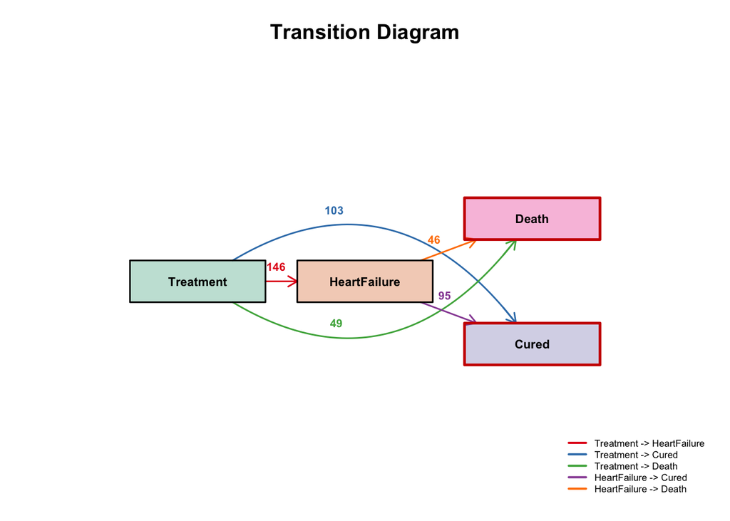

State transition diagram with event counts.

```r
plot_transition_diagram(ms, msdata)
```

## 6. Aalen-Johansen Nonparametric Estimates

```r
aj <- aalen_johansen(msdata)
print(aj)
```

```
#> Aalen-Johansen Estimate
#>   Time range: [1, 632]
#>   Event times: 251
#>   States: Treatment, HeartFailure, Cured, Death
#>   Common initial state: Treatment
#>   Uncertainty: point estimates only
#>
#> Event counts per transition:
#>          from           to n_events
#>     Treatment HeartFailure      146
#>     Treatment        Cured      103
#>     Treatment        Death       49
#>  HeartFailure        Cured       95
#>  HeartFailure        Death       46
#>
#> Final state occupation probabilities:
#>   Treatment: 0
#>   HeartFailure: 0
#>   Cured: 0.6771
#>   Death: 0.3229
```

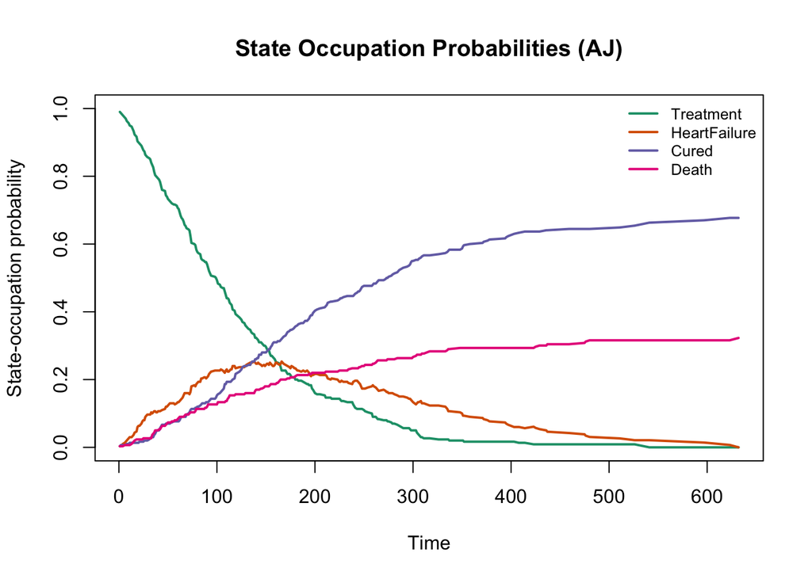

State occupation probabilities (Aalen-Johansen).

```r
plot(aj, type = "state_occupation")
```

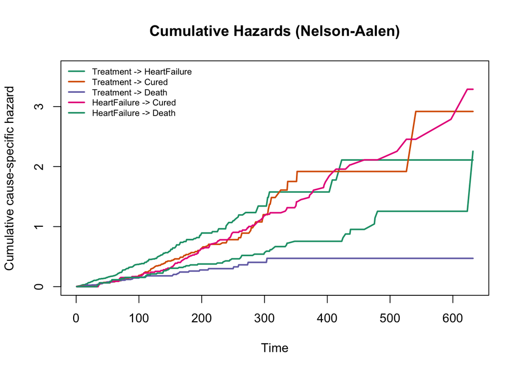

Nelson-Aalen cumulative hazards by transition.

```r
plot(aj, type = "cumulative_hazard")
```

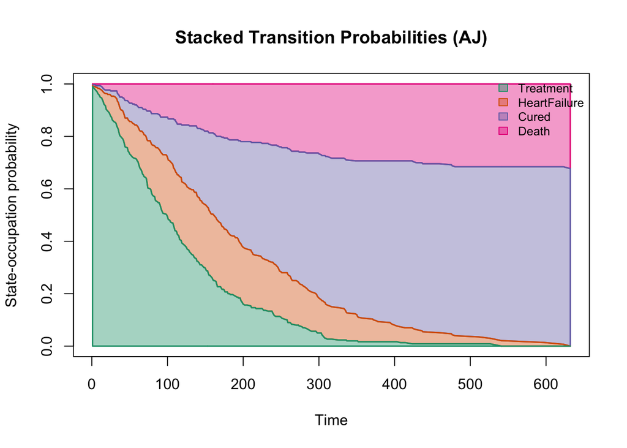

Transition probabilities from Treatment state (AJ).

```r
plot(aj, type = "stacked_transition_prob")
```

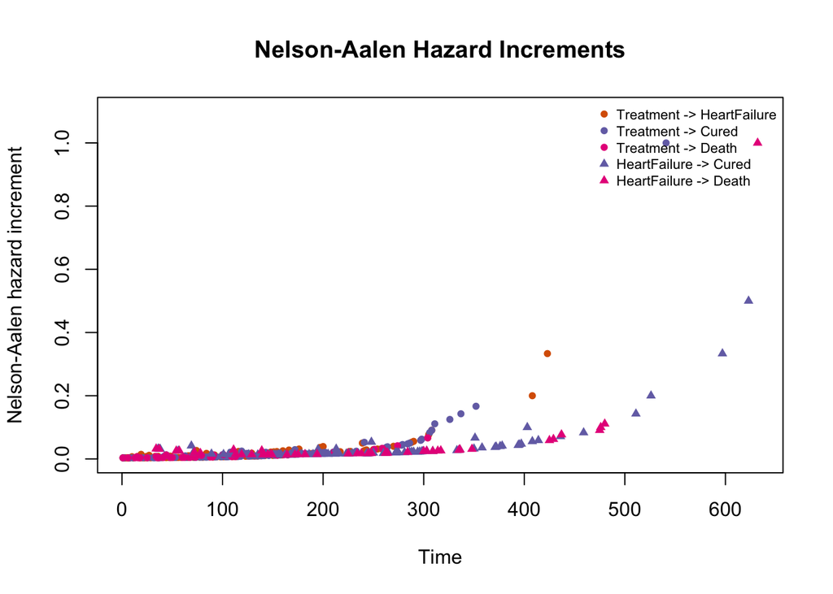

Nelson-Aalen hazard increments over time (AJ).

```r
plot(aj, type = "hazard_increment")
```

## 7. Fit Random Forest Model

```r
fit <- rfmstate(
  msdata,
  num.trees = canonical_trees,
  min_events = canonical_min_events,
  sparse_warning = canonical_sparse_warning,
  seed = canonical_seed
)
print(fit)
```

```
#> Clock-Reset Semi-Markov Random-Forest Model
#>   Common initial state: Treatment
#>   Time scale: duration since fresh state entry
#>   Covariates: gender, trt, weight
#>   Trees per edge: 200
#>   min_events safeguard: 3
#>
#> Fitted edge models:
#>   Treatment->HeartFailure: 300 sojourns, 146 target, 152 competing, 2 externally censored; OOB C = 0.6117, OOB coverage = 1.000
#>   Treatment->Cured: 300 sojourns, 103 target, 195 competing, 2 externally censored; OOB C = 0.4815, OOB coverage = 1.000
#>   Treatment->Death: 300 sojourns, 49 target, 249 competing, 2 externally censored; OOB C = 0.3867, OOB coverage = 1.000
#>   HeartFailure->Cured: 146 sojourns, 95 target, 46 competing, 5 externally censored; OOB C = 0.4608, OOB coverage = 1.000
#>   HeartFailure->Death: 146 sojourns, 46 target, 95 competing, 5 externally censored; OOB C = 0.4809, OOB coverage = 1.000
```

## 8. Model Summary

```r
s <- summary(fit)
```

## 9. Feature Importance

```r
imp <- importance(fit)
print(imp)
```

```
#> Feature Importance per Transition
#> ============================================================
#>
#>        Treatment->HeartFailure Treatment->Cured Treatment->Death
#> gender                 -0.0015          -0.0085          -0.0185
#> trt                     0.0263           0.0340          -0.0180
#> weight                  0.0455          -0.0025          -0.0147
#>        HeartFailure->Cured HeartFailure->Death
#> gender             -0.0001             -0.0079
#> trt                 0.0057             -0.0120
#> weight             -0.0088              0.0175
#>
#> Top variables per transition:
#>   Treatment->HeartFailure: weight (0.0455)
#>   Treatment->Cured: trt (0.034)
#>   Treatment->Death: weight (-0.0147)
#>   HeartFailure->Cured: trt (0.0057)
#>   HeartFailure->Death: weight (0.0175)
```

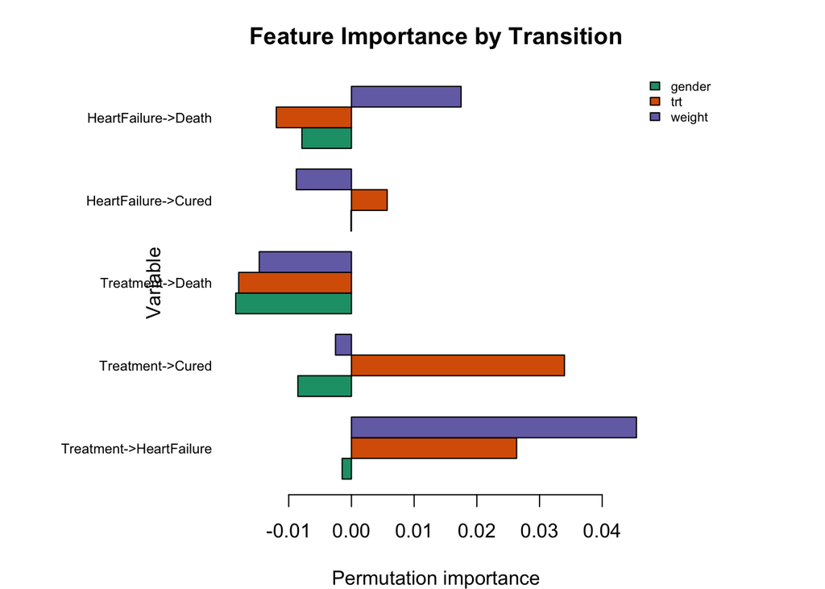

Feature importance per transition.

```r
plot(imp, type = "barplot")
```

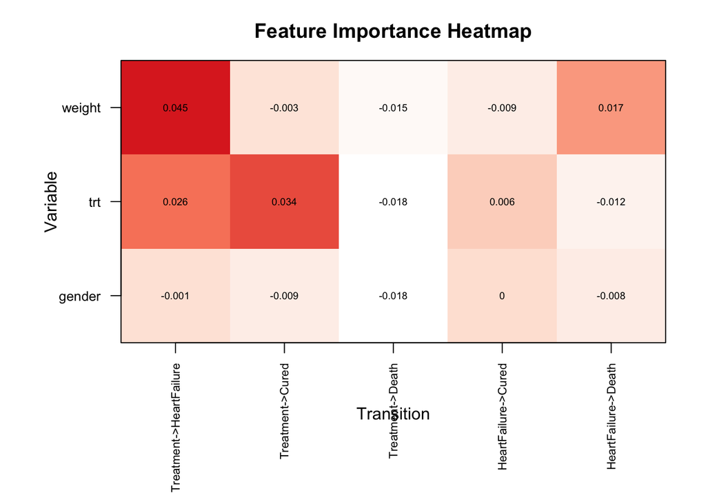

Feature importance heatmap.

```r
plot(imp, type = "heatmap")
```

## 10. Predict for New Patients

```r
new_patients <- data.frame(
  gender = c(1, 0, 1),
  trt = c(1, 0, 1),
  weight = c(65, 90, 75)
)
rownames(new_patients) <- c("Light male, Drug A",
                             "Heavy female, Drug B",
                             "Average male, Drug A")
print(new_patients)
```

```
#>                      gender trt weight
#> Light male, Drug A        1   1     65
#> Heavy female, Drug B      0   0     90
#> Average male, Drug A      1   1     75
```

```r
prediction_horizon <- floor(min(fit$max_duration_by_origin))
prediction_times <- sort(unique(c(
  0, seq(30, prediction_horizon, by = 30), prediction_horizon
)))
# This date-based example has integer-day event times, so an integer-day
# initial grid aligns with the observed hazard jumps before refinement.
pred <- predict(fit, newdata = new_patients, times = prediction_times,
                grid_step = 1)
print(pred)
```

```
#> Entry-Conditioned RFmstate Predictions
#>   Profiles: 3
#>   Starting state: Treatment
#>   Conditioning: fresh entry at duration zero
#>   Time scale: clock-reset
#>   Prediction type: new profiles
#>   Elapsed-time range: [0, 541]
#>   Extrapolation: none
```

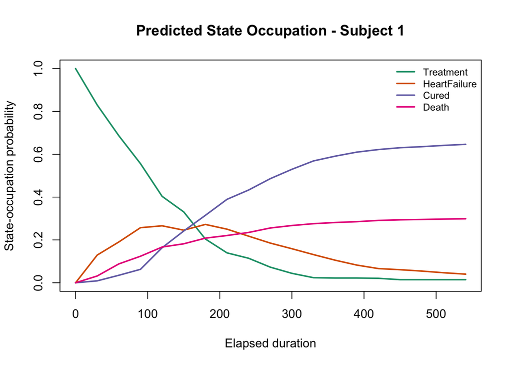

Predicted state occupation: light male on Drug A.

```r
plot(pred, type = "state_occupation", subject = 1)
```

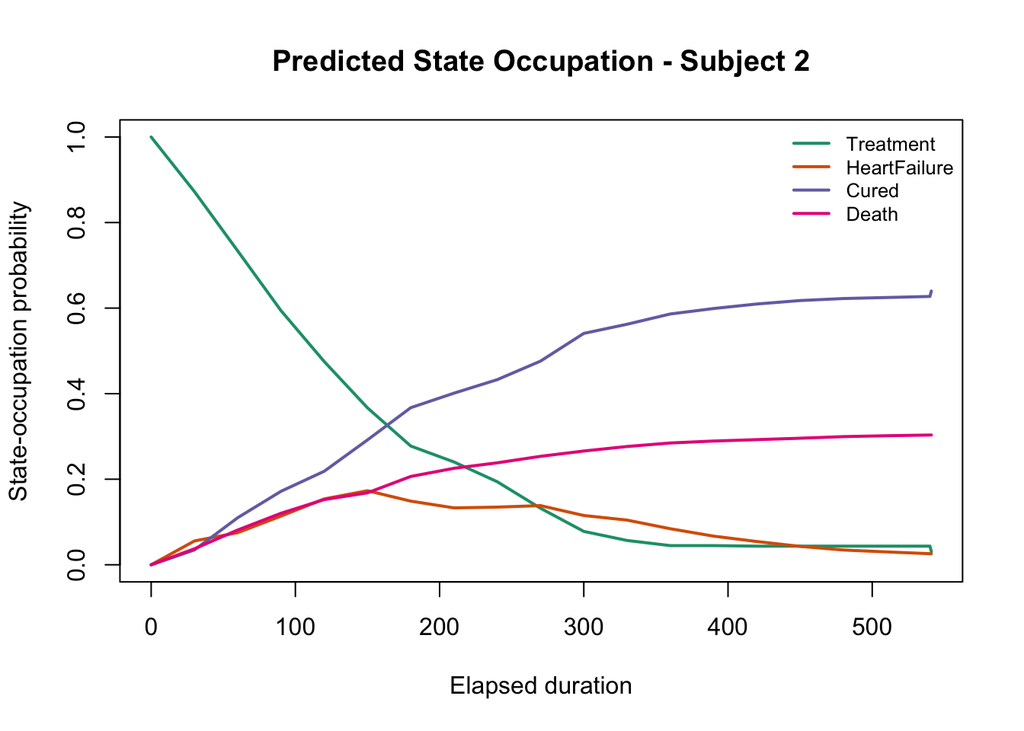

Predicted state occupation: heavy female on Drug B.

```r
plot(pred, type = "state_occupation", subject = 2)
```

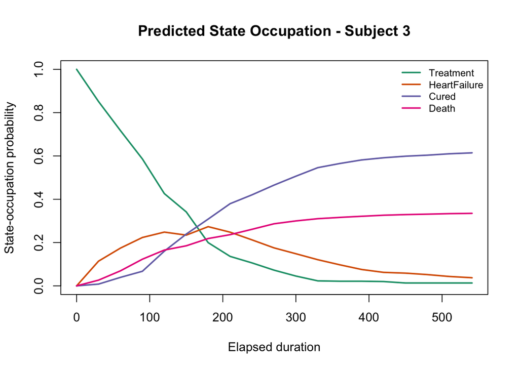

Predicted state occupation: average male on Drug A.

```r
plot(pred, type = "state_occupation", subject = 3)
```

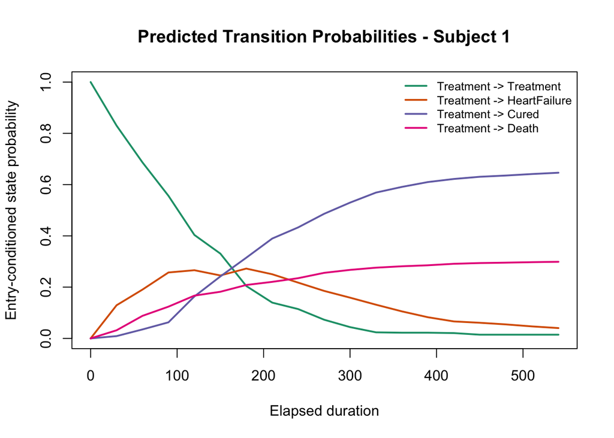

Predicted transition probabilities: light male on Drug A.

```r
plot(pred, type = "transition_prob", subject = 1)
```

All four prediction figures come from the same fitted object and prediction grid. They are conditional on fresh entry into `Treatment` at elapsed day zero; the transition-probability view exposes only that selected starting-state row, not a general all-start-state Markov matrix.

## 11. Diagnostics

```r
diag <- diagnose(fit)
print(diag)
```

```
#> RFmstate Diagnostics
#>   Validation label: edge-level ranger OOB only
#>
#> Genuine ranger edge OOB concordance:
#>               transition n_target_events n_competing_exits n_external_censored
#>  Treatment->HeartFailure             146               152                   2
#>         Treatment->Cured             103               195                   2
#>         Treatment->Death              49               249                   2
#>      HeartFailure->Cured              95                46                   5
#>      HeartFailure->Death              46                95                   5
#>  prediction_error oob_concordance oob_fraction replace sample_fraction
#>         0.3882907       0.6117093            1    TRUE               1
#>         0.5185383       0.4814617            1    TRUE               1
#>         0.6133056       0.3866944            1    TRUE               1
#>         0.5391995       0.4608005            1    TRUE               1
#>         0.5191125       0.4808875            1    TRUE               1
```

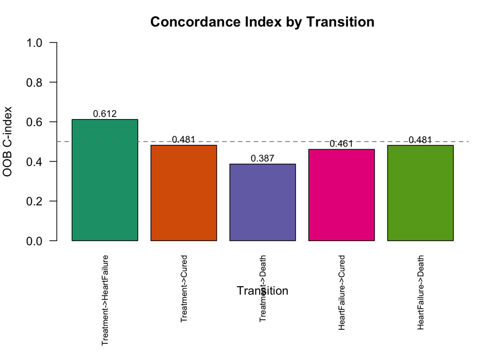

Concordance index by transition.

```r
plot(diag, type = "concordance")
```

Patient-level cross-validation is required for full-state IPCW Brier scores:

Each refit learns factor levels and numeric ranges from its training subjects only. A held-out-only factor level fails explicitly, while successful results retain exact subject assignments, assignment/refit seeds, per-edge event counts, support, and censoring-stability metadata. Confirmatory analyses should supply `eval_times` explicitly as below.

```r
cv_diag <- diagnose(fit, method = "cv", folds = 5,
                    eval_times = seq(0, prediction_horizon * 0.8,
                                     length.out = 9))
plot(cv_diag, type = "brier")
```

[output not shown]

## 12. Comparing Treatment Arms

We can compare predicted outcomes between Drug A and Drug B for an average patient.

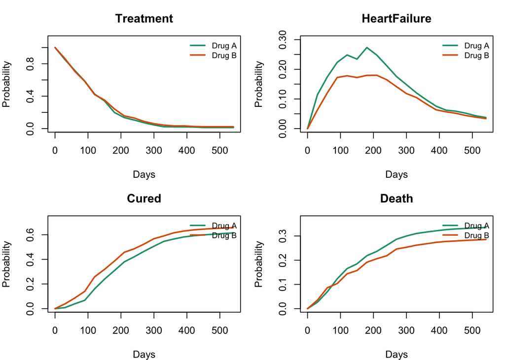

```r
drug_a <- data.frame(gender = 1, trt = 1, weight = 75)
drug_b <- data.frame(gender = 1, trt = 0, weight = 75)

pred_a <- predict(fit, newdata = drug_a, times = prediction_times,
                  grid_step = 1)
pred_b <- predict(fit, newdata = drug_b, times = prediction_times,
                  grid_step = 1)

times <- pred_a$time
states <- ms$state_names

par(mfrow = c(2, 2), mar = c(4, 4, 3, 1))
cols <- c("#1b9e77", "#d95f02")
for (j in seq_along(states)) {
  occ_a <- pred_a$state_occ[1, j, ]
  occ_b <- pred_b$state_occ[1, j, ]
  plot(times, occ_a, type = "l", col = cols[1], lwd = 2,
       ylim = c(0, max(c(occ_a, occ_b)) * 1.1),
       xlab = "Days", ylab = "Probability",
       main = states[j])
  lines(times, occ_b, col = cols[2], lwd = 2)
  legend("topright", legend = c("Drug A", "Drug B"),
         col = cols, lwd = 2, bty = "n", cex = 0.8)
}
```